# Exploratory Data Analysis Report

Report by dlookr package

2021-06-16

# 1 Introduction

The EDA Report provides exploratory data analysis information on objects that inherit data.frame and data.frame.

## 1.1 Information of Dataset

The dataset that generated the EDA Report is an **‘data.frame’** object. It consists of **7,042 observations** and **29 variables**.

## 1.2 Information of Variables

The variable information of the data set that generated the EDA Report is shown in the following table.:

Information of Variables

| variables | types | missing_count | missing_percent | unique_count | unique_rate |
| --- | --- | --- | --- | --- | --- |
| Opération | character | 0 | 0.00 | 130 | 0.018 |
| Division | integer | 0 | 0.00 | 5 | 0.001 |
| Description | character | 0 | 0.00 | 5 | 0.001 |
| Designation | character | 0 | 0.00 | 130 | 0.018 |
| TypeUnité | character | 0 | 0.00 | 7 | 0.001 |
| TypeProduit | character | 0 | 0.00 | 40 | 0.006 |
| NombreUnité | numeric | 0 | 0.00 | 1 | 0.000 |
| StatutADV | numeric | 2 | 0.03 | 4 | 0.001 |
| N..Lot | character | 0 | 0.00 | 2973 | 0.422 |
| Superficie | numeric | 0 | 0.00 | 498 | 0.071 |
| PrixUnitaire | numeric | 0 | 0.00 | 798 | 0.113 |
| PrixTotal | numeric | 0 | 0.00 | 1713 | 0.243 |
| TitreFoncier | character | 0 | 0.00 | 1049 | 0.149 |
| NuméroClient | character | 0 | 0.00 | 6118 | 0.869 |
| Client | character | 0 | 0.00 | 3000 | 0.426 |
| CIN.RC | character | 0 | 0.00 | 6047 | 0.859 |
| Dossier | character | 0 | 0.00 | 7042 | 1.000 |
| TypeDocument | character | 0 | 0.00 | 6 | 0.001 |
| Désignation.type.de.document | character | 0 | 0.00 | 6 | 0.001 |
| Création | Date | 14 | 0.20 | 1605 | 0.228 |
| Vers1 | numeric | 0 | 0.00 | 1359 | 0.193 |
| Vers2 | numeric | 0 | 0.00 | 1069 | 0.152 |
| Vers3 | numeric | 0 | 0.00 | 794 | 0.113 |
| TotalVersement | numeric | 0 | 0.00 | 2099 | 0.298 |
| VersRegularis | numeric | 0 | 0.00 | 4 | 0.001 |
| TropPerçuRéglé | numeric | 0 | 0.00 | 7 | 0.001 |
| TropPerçuNonRéglé | numeric | 0 | 0.00 | 39 | 0.006 |
| ResteàPayer | numeric | 0 | 0.00 | 2647 | 0.376 |
| TotalAvances | numeric | 0 | 0.00 | 2092 | 0.297 |

The target variable of the data is **‘NULL’**, and the data type of the variable is **NULL(You did not specify a target variable)**.

## 1.3 About EDA Report

EDA reports provide information and visualization results that support the EDA process. In particular, it provides a variety of information to understand the relationship between the target variable and the rest of the variables of interest.

# 2 Univariate Analysis

## 2.1 Descriptive Statistics

edaData  
29 Variables 7042 Observations

Opération

| n | missing | distinct |
| --- | --- | --- |
| 7042 | 0 | 130 |

| lowest : | 180011.01 | 180017.01 | 180018.01 | 180023.01 | 180025.01 |
| --- | --- | --- | --- | --- | --- |
| highest: | 180620.01 | 180621.01 | 180621.02 | 180621.03 | 180630.02 |

Division

| n | missing | distinct | Info | Mean | Gmd |
| --- | --- | --- | --- | --- | --- |
| 7042 | 0 | 5 | 0.929 | 1803 | 1.38 |

lowest : 1801 1802 1803 1804 1805 , highest: 1801 1802 1803 1804 1805

```
 Value       1801  1802  1803  1804  1805
 Frequency    299  1412  2129   956  2246
 Proportion 0.042 0.201 0.302 0.136 0.319
```

Description

| n | missing | distinct |
| --- | --- | --- |
| 7042 | 0 | 5 |

| lowest : | Agence Oujda | Berkane | Jerada-Figuig | Nador - Driouch | Taourirt |
| --- | --- | --- | --- | --- | --- |
| highest: | Agence Oujda | Berkane | Jerada-Figuig | Nador - Driouch | Taourirt |

```
 Value         Agence Oujda         Berkane   Jerada-Figuig Nador - Driouch
 Frequency              299            1412             956            2129
 Proportion           0.042           0.201           0.136           0.302

 Value             Taourirt
 Frequency             2246
 Proportion           0.319
```

Designation

| n | missing | distinct |
| --- | --- | --- |
| 7042 | 0 | 130 |

| lowest : | 10131-POLE URBAIN AL AROUIT TR1 | 10132-POLE URBAIN AL AROUIT TR2 | 10133-POLE URBAIN AL AROUIT TR3 ET TR4 | 10201-WIFAK OUJDA | 10211-WIFAK ls à 140000 HT |
| --- | --- | --- | --- | --- | --- |
| highest: | PU JNAN KERT DRIOUCH | RESIDENCE FERMEE R+1 GREEN HOUSE SAIDIA | RESIDENCE GREEN HOUSE R+3 | ZAE guenfouda tr1 | ZUN BOUGHRIBA EXTENSION |

TypeUnité

| n | missing | distinct |
| --- | --- | --- |
| 7042 | 0 | 7 |

| lowest : | CONSTRUCTION LOGEMENT | CONSTRUCTION USAGE COMM. | ILOT | LOT ACTIVITÉ COMMERCIALE | LOT EQUIPEMENT PUBLIC |
| --- | --- | --- | --- | --- | --- |
| highest: | ILOT | LOT ACTIVITÉ COMMERCIALE | LOT EQUIPEMENT PUBLIC | LOT HABITATION | PRODUITS TIERS |

CONSTRUCTION LOGEMENT (527, 0.075), CONSTRUCTION USAGE COMM. (100, 0.014), ILOT (4, 0.001), LOT ACTIVITÉ COMMERCIALE (383, 0.054), LOT EQUIPEMENT PUBLIC (15, 0.002), LOT HABITATION (5563, 0.790), PRODUITS TIERS (450, 0.064)

TypeProduit

| n | missing | distinct |
| --- | --- | --- |
| 7042 | 0 | 40 |

| lowest : | CONSTR FAIBLE COUT 140MILLE | CONSTR LOCAUX COMMERCIAUX | CONSTR MOYEN& HAUT STANDING VILLA SEMI | CONSTR MOYEN& HAUT STANDING APPARTEMENT | CONSTR MOYEN& HAUT STANDING DUPLEX |
| --- | --- | --- | --- | --- | --- |
| highest: | LOTS PROMOTIONNELS R+6 | LOTS PROMOTIONNELS R+6 RDC COMMERCIAL | LOTS PROMOTIONNELS VILLA BANDE | LOTS PROMOTIONNELS VILLA ISOLEES | LOTS PROMOTIONNELS VILLA JUMELEES |

NombreUnité

| n | missing | distinct | Info | Mean | Gmd |
| --- | --- | --- | --- | --- | --- |
| 7042 | 0 | 1 | 0 | 1 | 0 |

```
 Value         1
 Frequency  7042
 Proportion    1
```

StatutADV

| n | missing | distinct | Info | Mean | Gmd |
| --- | --- | --- | --- | --- | --- |
| 7040 | 2 | 3 | 0.681 | 2.35 | 0.4586 |

```
 Value          2     3     5
 Frequency   4594  2437     9
 Proportion 0.653 0.346 0.001
```

N..Lot

| n | missing | distinct |
| --- | --- | --- |
| 7042 | 0 | 2973 |

| lowest : | 1 | 1-1-A | 1-2-C | 10 | 10-1-C |
| --- | --- | --- | --- | --- | --- |
| highest: | V42 | V46 | V54 | V56 | V7 |

Superficie

| n | missing | distinct | Info | Mean | Gmd | .05 | .10 | .25 | .50 | .75 | .90 | .95 |
| --- | --- | --- | --- | --- | --- | --- | --- | --- | --- | --- | --- | --- |
| 7042 | 0 | 498 | 0.998 | 150 | 95.92 | 65.0 | 70.0 | 99.0 | 120.0 | 157.0 | 224.9 | 285.1 |

lowest : 10 12 13 14 15 , highest: 3769 4244 5153 5252 21020

```
 Value          0   200   400   600   800  1000  1200  1400  1600  2000  2400  2600
 Frequency   2654  4080   207    60    13     3     6     3     1     1     1     2
 Proportion 0.377 0.579 0.029 0.009 0.002 0.000 0.001 0.000 0.000 0.000 0.000 0.000

 Value       2800  3000  3600  3800  4200  5200 21000
 Frequency      1     2     2     2     1     2     1
 Proportion 0.000 0.000 0.000 0.000 0.000 0.000 0.000
```

For the frequency table, variable is rounded to the nearest 200

PrixUnitaire

| n | missing | distinct | Info | Mean | Gmd | .05 | .10 | .25 | .50 | .75 | .90 | .95 |
| --- | --- | --- | --- | --- | --- | --- | --- | --- | --- | --- | --- | --- |
| 7042 | 0 | 798 | 0.999 | 2049 | 2027 | 397 | 500 | 850 | 1312 | 1929 | 2825 | 4543 |

| lowest : | 0.00 | 59.41 | 60.00 | 60.61 | 61.86 |
| --- | --- | --- | --- | --- | --- |
| highest: | 16428.57 | 17692.31 | 21207.77 | 170300.00 | 2600000.00 |

```
 Value            0   20000  180000 2600000
 Frequency     7011      29       1       1
 Proportion   0.996   0.004   0.000   0.000
```

For the frequency table, variable is rounded to the nearest 20000

PrixTotal

| n | missing | distinct | Info | Mean | Gmd | .05 | .10 | .25 | .50 | .75 | .90 | .95 |
| --- | --- | --- | --- | --- | --- | --- | --- | --- | --- | --- | --- | --- |
| 7042 | 0 | 1713 | 1 | 222325 | 190205 | 48005 | 56000 | 110000 | 153535 | 299508 | 423000 | 537140 |

lowest : 0 5000 5880 5940 6000 , highest: 3397438 3407840 4872696 17030000 26000000

```
 Value      0.0e+00 2.0e+05 4.0e+05 6.0e+05 8.0e+05 1.0e+06 1.2e+06 1.4e+06 1.6e+06
 Frequency     1705    3680    1245     270      68      39      14       6       3
 Proportion   0.242   0.523   0.177   0.038   0.010   0.006   0.002   0.001   0.000

 Value      2.0e+06 2.2e+06 2.6e+06 2.8e+06 3.4e+06 4.8e+06 1.7e+07 2.6e+07
 Frequency        2       1       3       1       2       1       1       1
 Proportion   0.000   0.000   0.000   0.000   0.000   0.000   0.000   0.000
```

For the frequency table, variable is rounded to the nearest 200000

TitreFoncier

| n | missing | distinct |
| --- | --- | --- |
| 7042 | 0 | 1049 |

| lowest : | - |  | 101204 | 102265 | 11/65263 |
| --- | --- | --- | --- | --- | --- |
| highest: | HC2 | HE2 | LOT ECONO R+2 COM | LOT ECONO R+2 HAB | N.DISPO |

NuméroClient

| n | missing | distinct |
| --- | --- | --- |
| 7042 | 0 | 6118 |

lowest : 10000877 10003915 10005092 10005146 10005464 , highest: 11126953 11126974 11127003 11127049 11127243

Client

| n | missing | distinct |
| --- | --- | --- |
| 7042 | 0 | 3000 |

| lowest : | Abagael Autry | Abbey Divers | Abbott Broome | Abbott McCambrois | Abdel Deex |
| --- | --- | --- | --- | --- | --- |
| highest: | Zola Foltin | Zola Kettell | Zollie Berrill | Zollie Fullilove | Zolly Langlais |

CIN.RC

| n | missing | distinct |
| --- | --- | --- |
| 7042 | 0 | 6047 |

lowest : #VALEUR! A118052 A154093 A217174 A230388 , highest: ZZ9326 ZZ9332 ZZ9338 ZZ9342 ZZ9345

Dossier

| n | missing | distinct |
| --- | --- | --- |
| 7042 | 0 | 7042 |

| lowest : | 21211742 | 21211773 | 21211791 | 21211793 | 21211794 |
| --- | --- | --- | --- | --- | --- |
| highest: | 26000123 | 26000124 | 26000125 | 26000127 | U60086 |

TypeDocument

| n | missing | distinct |
| --- | --- | --- |
| 7042 | 0 | 6 |

lowest : 21226086 ZAF ZCD ZEQ ZOP , highest: ZAF ZCD ZEQ ZOP ZVL

```
 Value      21226086      ZAF      ZCD      ZEQ      ZOP      ZVL
 Frequency         1      335       38       14       28     6626
 Proportion    0.000    0.048    0.005    0.002    0.004    0.941
```

Désignation.type.de.document

| n | missing | distinct |
| --- | --- | --- |
| 7042 | 0 | 6 |

| lowest : | Vente Affectation | Vente conditionnée | Vente Equip public | Vente libre | Vente offre prix |
| --- | --- | --- | --- | --- | --- |
| highest: | Vente conditionnée | Vente Equip public | Vente libre | Vente offre prix | ZVL |

```
 Value       Vente Affectation Vente conditionnée Vente Equip public
 Frequency                 335                 38                 14
 Proportion              0.048              0.005              0.002

 Value             Vente libre   Vente offre prix                ZVL
 Frequency                6626                 28                  1
 Proportion              0.941              0.004              0.000
```

Création

```
          n    missing   distinct       Info       Mean        Gmd        .05
       7028         14       1604          1 2016-08-27       1562 2009-01-01
        .10        .25        .50        .75        .90        .95
 2013-09-11 2014-12-03 2017-11-20 2019-07-15 2020-06-12 2020-11-26
```

| lowest : | 1955-05-03 | 1985-02-21 | 1988-01-01 | 1988-02-11 | 1988-03-09 |
| --- | --- | --- | --- | --- | --- |
| highest: | 2021-05-06 | 2021-05-07 | 2021-05-10 | 2021-05-11 | 2021-05-17 |

Vers1

| n | missing | distinct | Info | Mean | Gmd | .05 | .10 | .25 | .50 | .75 | .90 | .95 |
| --- | --- | --- | --- | --- | --- | --- | --- | --- | --- | --- | --- | --- |
| 7042 | 0 | 1359 | 1 | 71289 | 67443 | 5000 | 14700 | 34000 | 46759 | 86625 | 130000 | 175000 |

lowest : 0 1000 1242 2000 2310 , highest: 1703920 3410887 3800000 4500000 20160113

```
 Value             0   200000   400000   600000   800000  1000000  1200000  1800000
 Frequency      5788     1150       85        8        1        2        3        1
 Proportion    0.822    0.163    0.012    0.001    0.000    0.000    0.000    0.000

 Value       3400000  3800000  4400000 20200000
 Frequency         1        1        1        1
 Proportion    0.000    0.000    0.000    0.000
```

For the frequency table, variable is rounded to the nearest 200000

Vers2

| n | missing | distinct | Info | Mean | Gmd | .05 | .10 | .25 | .50 | .75 | .90 | .95 |
| --- | --- | --- | --- | --- | --- | --- | --- | --- | --- | --- | --- | --- |
| 7042 | 0 | 1069 | 0.962 | 35706 | 42489 | 0 | 0 | 0 | 29664 | 49500 | 90000 | 112320 |

lowest : 0 1000 1250 1400 1450 , highest: 384800 421500 500000 918668 4000000

```
 Value            0   50000  100000  150000  200000  250000  300000  350000  400000
 Frequency     3363    2685     744     161      42      28      13       1       2
 Proportion   0.478   0.381   0.106   0.023   0.006   0.004   0.002   0.000   0.000

 Value       500000  900000 4000000
 Frequency        1       1       1
 Proportion   0.000   0.000   0.000
```

For the frequency table, variable is rounded to the nearest 50000

Vers3

| n | missing | distinct | Info | Mean | Gmd | .05 | .10 | .25 | .50 | .75 | .90 | .95 |
| --- | --- | --- | --- | --- | --- | --- | --- | --- | --- | --- | --- | --- |
| 7042 | 0 | 794 | 0.693 | 20347 | 33362 | 0 | 0 | 0 | 0 | 24000 | 66000 | 100000 |

| lowest : | 0.00 | 401.62 | 500.00 | 850.00 | 890.00 |
| --- | --- | --- | --- | --- | --- |
| highest: | 409181.00 | 415000.00 | 477500.00 | 2203800.00 | 5545000.00 |

```
 Value            0   50000  100000  150000  200000  250000  300000  350000  400000
 Frequency     5316    1158     355     127      49      18       9       3       4
 Proportion   0.755   0.164   0.050   0.018   0.007   0.003   0.001   0.000   0.001

 Value       500000 2200000 5550000
 Frequency        1       1       1
 Proportion   0.000   0.000   0.000
```

For the frequency table, variable is rounded to the nearest 50000

TotalVersement

| n | missing | distinct | Info | Mean | Gmd | .05 | .10 | .25 | .50 | .75 | .90 | .95 |
| --- | --- | --- | --- | --- | --- | --- | --- | --- | --- | --- | --- | --- |
| 7042 | 0 | 2099 | 1 | 124438 | 112704 | 10000 | 27500 | 50000 | 90750 | 156000 | 260000 | 336775 |

VersRegularis

| n | missing | distinct | Info | Mean | Gmd |
| --- | --- | --- | --- | --- | --- |
| 7042 | 0 | 4 | 0.001 | 4.544 | 9.086 |

```
 Value          0  6000 11000 15000
 Frequency   7039     1     1     1
 Proportion     1     0     0     0
```

TropPerçuRéglé

| n | missing | distinct | Info | Mean | Gmd |
| --- | --- | --- | --- | --- | --- |
| 7042 | 0 | 7 | 0.003 | 28.35 | 56.68 |

lowest : 0 1785 6500 20000 26000 , highest: 6500 20000 26000 45370 50000

```
 Value          0  1785  6500 20000 26000 45370 50000
 Frequency   7035     1     1     1     1     1     2
 Proportion 0.999 0.000 0.000 0.000 0.000 0.000 0.000
```

TropPerçuNonRéglé

| n | missing | distinct | Info | Mean | Gmd | .05 | .10 | .25 | .50 | .75 | .90 | .95 |
| --- | --- | --- | --- | --- | --- | --- | --- | --- | --- | --- | --- | --- |
| 7042 | 0 | 39 | 0.019 | 132.3 | 264.2 | 0 | 0 | 0 | 0 | 0 | 0 | 0 |

| lowest : | 0.00 | 0.01 | 30.00 | 80.00 | 192.00 |
| --- | --- | --- | --- | --- | --- |
| highest: | 57657.60 | 57690.00 | 81336.00 | 95567.50 | 140000.00 |

ResteàPayer

```
        n  missing distinct     Info     Mean      Gmd      .05      .10      .25
     7042        0     2647    0.996    98002   120798        0        0    17000
      .50      .75      .90      .95
    52634   123938   234859   310869
```

| lowest : | 0.00 | 0.40 | 0.50 | 60.00 | 68.75 |
| --- | --- | --- | --- | --- | --- |
| highest: | 1864200.00 | 2626000.00 | 2809719.00 | 3685000.00 | 21500000.00 |

```
 Value             0   200000   400000   600000   800000  1000000  1200000  1400000
 Frequency      4900     1758      257       72       26       13        4        3
 Proportion    0.696    0.250    0.036    0.010    0.004    0.002    0.001    0.000

 Value       1600000  1800000  2600000  2800000  3600000 21600000
 Frequency         3        2        1        1        1        1
 Proportion    0.000    0.000    0.000    0.000    0.000    0.000
```

For the frequency table, variable is rounded to the nearest 200000

TotalAvances

| n | missing | distinct | Info | Mean | Gmd | .05 | .10 | .25 | .50 | .75 | .90 | .95 |
| --- | --- | --- | --- | --- | --- | --- | --- | --- | --- | --- | --- | --- |
| 7042 | 0 | 2092 | 1 | 216039 | 303264 | 0 | 17000 | 46200 | 90000 | 156000 | 260581 | 336798 |

| lowest : | 0 | 1242 | 2000 | 3000 | 3720 |
| --- | --- | --- | --- | --- | --- |
| highest: | 2430636 | 3410887 | 4500000 | 13345000 | 661356500 |

```
 Value      0.0e+00 5.0e+06 1.5e+07 6.6e+08
 Frequency     7038       2       1       1
 Proportion   0.999   0.000   0.000   0.000
```

For the frequency table, variable is rounded to the nearest 5000000

## 2.2 Normality Test of Numerical Variables

### 2.2.1 Statistics and Visualization of (Sample) Data

**[ Division ]**

normality test : Shapiro-Wilk normality test

```
 statistic : 0.8662,  p-value : 3.09445E-54
```

skewness and kurtosis

| type | skewness | kurtosis |
| --- | --- | --- |
| original | -0.1431077 | 1.810732 |
| log transformation | -0.1439270 | 1.811706 |
| sqrt transformation | -0.1435172 | 1.811219 |

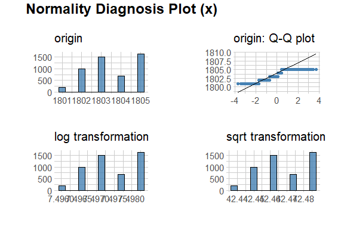

**[ StatutADV ]**

normality test : Shapiro-Wilk normality test

```
 statistic : 0.6067,  p-value : 4.80384E-75
```

skewness and kurtosis

| type | skewness | kurtosis |
| --- | --- | --- |
| original | 0.8179079 | 2.538209 |
| log transformation | 0.7024848 | 1.701481 |
| sqrt transformation | 0.7437052 | 1.974089 |

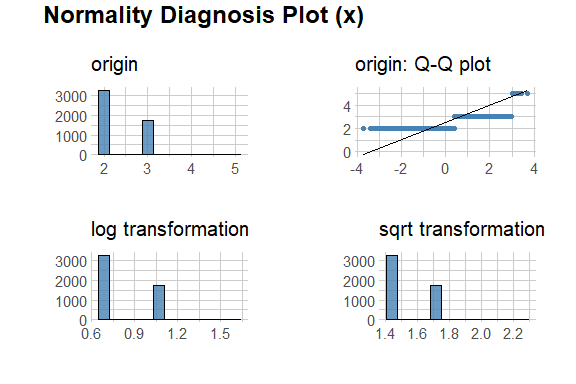

**[ Superficie ]**

normality test : Shapiro-Wilk normality test

```
 statistic : 0.28568,  p-value : 4.72713E-88
```

skewness and kurtosis

| type | skewness | kurtosis |
| --- | --- | --- |
| original | 16.4472669 | 385.578389 |
| log transformation | 0.7860488 | 8.908319 |
| sqrt transformation | 5.1944028 | 60.194167 |

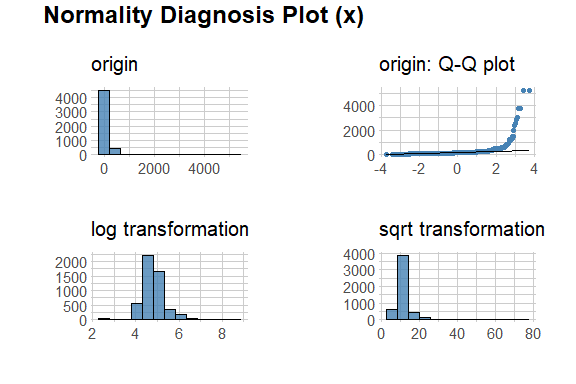

**[ PrixUnitaire ]**

normality test : Shapiro-Wilk normality test

```
 statistic : 0.00836,  p-value : 1.18236E-95
```

skewness and kurtosis

| type | skewness | kurtosis |
| --- | --- | --- |
| original | 70.065713 | 4937.55772 |
| log+1 transformation | -0.844539 | 12.24699 |
| sqrt transformation | 39.622016 | 2256.53708 |

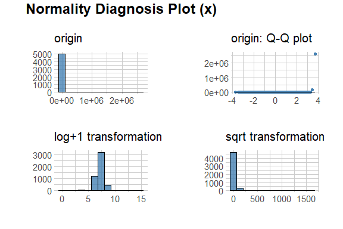

**[ PrixTotal ]**

normality test : Shapiro-Wilk normality test

```
 statistic : 0.16753,  p-value : 1.47034E-91
```

skewness and kurtosis

| type | skewness | kurtosis |
| --- | --- | --- |
| original | 39.306482 | 1913.61747 |
| log+1 transformation | -2.847758 | 37.22833 |
| sqrt transformation | 5.134069 | 98.49834 |

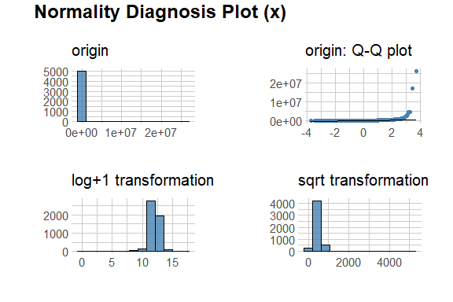

**[ Vers1 ]**

normality test : Shapiro-Wilk normality test

```
 statistic : 0.04355,  p-value : 8.42828E-95
```

skewness and kurtosis

| type | skewness | kurtosis |
| --- | --- | --- |
| original | 46.511522 | 2255.02725 |
| log+1 transformation | -3.976764 | 19.77045 |
| sqrt transformation | 12.446432 | 361.89082 |

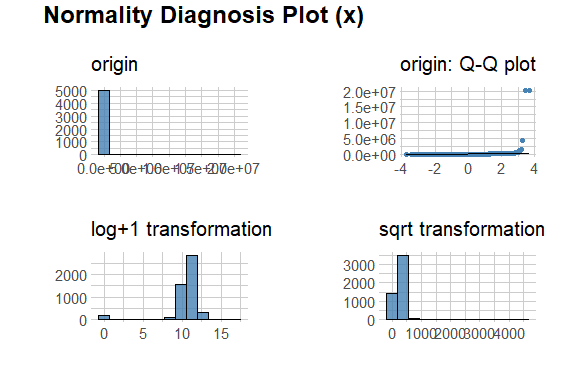

**[ Vers2 ]**

normality test : Shapiro-Wilk normality test

```
 statistic : 0.74039,  p-value : 1.28381E-66
```

skewness and kurtosis

| type | skewness | kurtosis |
| --- | --- | --- |
| original | 3.6094911 | 42.572113 |
| log+1 transformation | -0.6666363 | 1.507394 |
| sqrt transformation | 0.3284992 | 2.778566 |

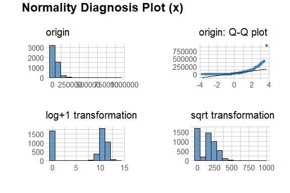

**[ Vers3 ]**

normality test : Shapiro-Wilk normality test

```
 statistic : 0.14781,  p-value : 4.21389E-92
```

skewness and kurtosis

| type | skewness | kurtosis |
| --- | --- | --- |
| original | 44.1700442 | 2504.685753 |
| log+1 transformation | 0.7169883 | 1.553379 |
| sqrt transformation | 2.7338825 | 29.342524 |

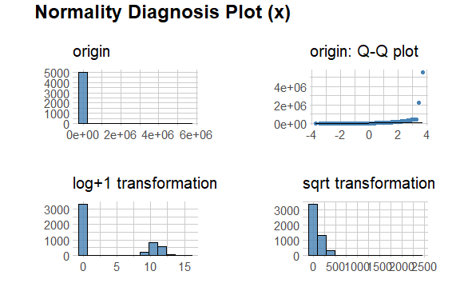

**[ TotalVersement ]**

normality test : Shapiro-Wilk normality test

```
 statistic : 0.23648,  p-value : 1.43548E-89
```

skewness and kurtosis

| type | skewness | kurtosis |
| --- | --- | --- |
| original | 36.932886 | 1932.05615 |
| log+1 transformation | -4.080336 | 20.93689 |
| sqrt transformation | 3.081948 | 50.60298 |

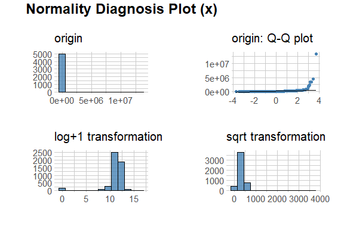

**[ VersRegularis ]**

normality test : Shapiro-Wilk normality test

```
 statistic : 0.00751,  p-value : 1.12812E-95
```

skewness and kurtosis

| type | skewness | kurtosis |
| --- | --- | --- |
| original | 40.78808 | 1664.667 |
| log+1 transformation | 40.78808 | 1664.667 |
| sqrt transformation | 40.78808 | 1664.667 |

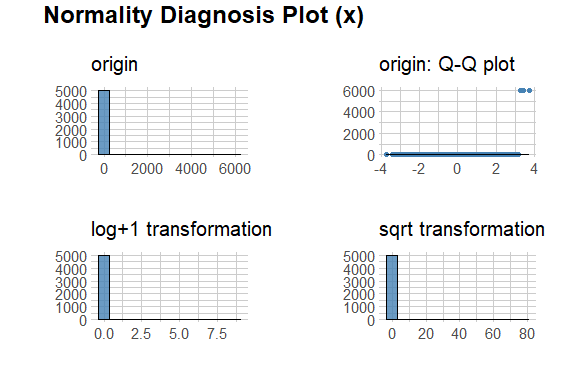

**[ TropPerçuRéglé ]**

normality test : Shapiro-Wilk normality test

```
 statistic : 0.01429,  p-value : 1.63903E-95
```

skewness and kurtosis

| type | skewness | kurtosis |
| --- | --- | --- |
| original | 30.54766 | 972.8601 |
| log+1 transformation | 24.04187 | 585.5213 |
| sqrt transformation | 27.53361 | 784.5465 |

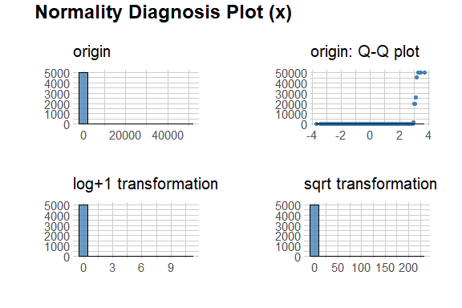

**[ TropPerçuNonRéglé ]**

normality test : Shapiro-Wilk normality test

```
 statistic : 0.01833,  p-value : 2.04951E-95
```

skewness and kurtosis

| type | skewness | kurtosis |
| --- | --- | --- |
| original | 34.25555 | 1374.2475 |
| log+1 transformation | 15.67261 | 253.9396 |
| sqrt transformation | 22.94274 | 596.5598 |

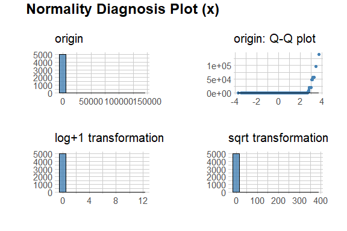

**[ ResteàPayer ]**

normality test : Shapiro-Wilk normality test

```
 statistic : 0.53963,  p-value : 2.25236E-78
```

skewness and kurtosis

| type | skewness | kurtosis |
| --- | --- | --- |
| original | 7.357963 | 111.945410 |
| log+1 transformation | -1.644799 | 4.088664 |
| sqrt transformation | 1.204688 | 7.193388 |

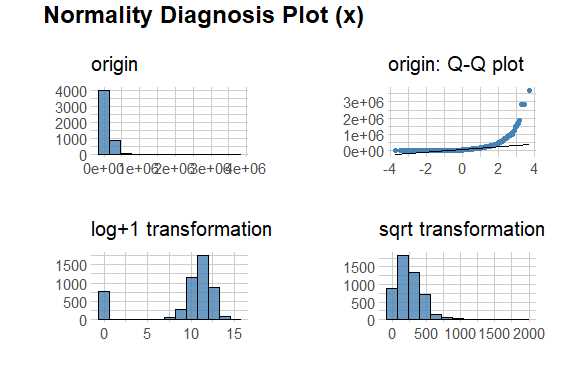

**[ TotalAvances ]**

normality test : Shapiro-Wilk normality test

```
 statistic : 0.61122,  p-value : 8.37503E-75
```

skewness and kurtosis

| type | skewness | kurtosis |
| --- | --- | --- |
| original | 9.7524771 | 246.447255 |
| log+1 transformation | -3.0298001 | 11.228284 |
| sqrt transformation | 0.8030601 | 8.305734 |

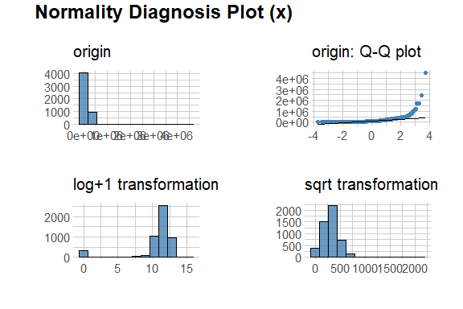

# 3 Relationship Between Variables

## 3.1 Correlation Coefficient

### 3.1.1 Correlation Coefficient by Variable Combination

Table of correlation coefficients (0.5 or more)

| Variable1 | Variable2 | Correlation Coefficient |
| --- | --- | --- |
| ResteàPayer | PrixTotal | 0.8927851 |
| ResteàPayer | PrixUnitaire | 0.8838962 |
| TotalVersement | Vers2 | 0.8313108 |
| TotalVersement | Vers3 | 0.8210494 |
| PrixTotal | PrixUnitaire | 0.7712828 |
| TotalVersement | PrixTotal | 0.7642227 |
| Vers3 | Vers2 | 0.7438568 |

### 3.1.2 Correlation Plot of Numerical Variables

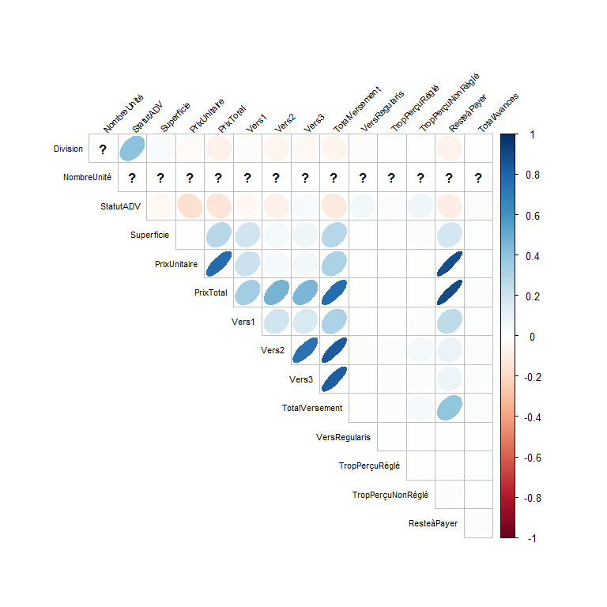

# 4 Target based Analysis

## 4.1 Grouped Descriptive Statistics

### 4.1.1 Grouped Numerical Variables

There is no target variable.

### 4.1.2 Grouped Categorical Variables

There is no target variable.

## 4.2 Grouped Relationship Between Variables

### 4.2.1 Grouped Correlation Coefficient

```
There is no target variable.
```

### 4.2.2 Grouped Correlation Plot of Numerical Variables

```
There is no target variable.
```